# DSC540 FINAL PROJECT

DePaul University  
Chicago, IL  
Can Dai

## Project Description

Dataset Chosen for this project: MNIST Dataset (https://www.kaggle.com/competitions/digit-recognizer/data)

In this project, I will try to develop a classifier that can most accurately identify digits in the MNIST dataset. In order to find the best model, I will try to develop and evaluate various models such as SVC, Random Forest, KNN and GaussianNB, and make use of hyperparamater optimization using grid search and PCA to optimize model performances.

The MNIST dataset is a widely used benchmark dataset in the field of machine learning and computer vision. It consists of a set of 70,000 handwritten digits (0-9) that have been normalized and centered in a fixed-size image format of 28x28 pixels. The dataset is split into two subsets: 60,000 images for training and 10,000 images for testing.

Due to its popularity and widespread use, the MNIST dataset has become a standard reference dataset for researchers in the field of machine learning and computer vision. It has also been used as a basis for developing and testing new algorithms and techniques for image recognition, classification, and other related applications.

## Import Libraries

```python
import pandas as pd
import numpy as np
import matplotlib.pyplot as plt
import seaborn as sns

from sklearn import metrics
from sklearn.model_selection import train_test_split, GridSearchCV
from sklearn.experimental import enable_halving_search_cv
from sklearn.model_selection import HalvingGridSearchCV
from sklearn.ensemble import RandomForestClassifier
from sklearn.neighbors import KNeighborsClassifier
from sklearn.naive_bayes import GaussianNB
from sklearn.svm import SVC
from sklearn.preprocessing import MinMaxScaler, StandardScaler, Binarizer
from sklearn.pipeline import Pipeline
from matplotlib.colors import ListedColormap
import itertools

from sklearn.metrics import confusion_matrix, accuracy_score, classification_report, f1_score, precision_score, recall_score
from sklearn.decomposition import PCA
np.random.seed(1)
```

### Import Dataset

```python
# Upload CSV files in
dataset_train = pd.read_csv('train.csv')
dataset_test = pd.read_csv('test.csv')
dataset_correct_test = pd.read_csv('submission.csv')
```

```python
# Correct Test Labels
correct_test_labels = dataset_correct_test['Label']
print(f"Shape of Correct Test Labels is: {correct_test_labels.shape}")
correct_test_labels.head()
```

```
Shape of Correct Test Labels is: (28000,)
```

```
0    2
1    0
2    9
3    0
4    3
Name: Label, dtype: int64
```

```python
# SHAPE
print(f"Shape of Training Data is: {dataset_train.shape}")
print(f"Shape of Test Data is: {dataset_test.shape}")
```

```
Shape of Training Data is: (42000, 785)
Shape of Test Data is: (28000, 784)
```

## Data Analysis & Visualization

Each image is 28 pixels in height and 28 pixels in width, for a total of 784 pixels in total. Each pixel has a single pixel-value associated with it, indicating the lightness or darkness of that pixel, with higher numbers meaning darker. This pixel-value is an integer between 0 and 255, inclusive.

The training data set, (train.csv), has 785 columns. The first column, called "label", is the digit that was drawn by the user. The rest of the columns contain the pixel-values of the associated image.

```python
dataset_train.head(5)
```

|  | label | pixel0 | pixel1 | pixel2 | pixel3 | pixel4 | pixel5 | pixel6 | pixel7 | pixel8 | ... | pixel774 | pixel775 | pixel776 | pixel777 | pixel778 | pixel779 | pixel780 | pixel781 | pixel782 | pixel783 |
| --- | --- | --- | --- | --- | --- | --- | --- | --- | --- | --- | --- | --- | --- | --- | --- | --- | --- | --- | --- | --- | --- |
| 0 | 1 | 0 | 0 | 0 | 0 | 0 | 0 | 0 | 0 | 0 | ... | 0 | 0 | 0 | 0 | 0 | 0 | 0 | 0 | 0 | 0 |
| 1 | 0 | 0 | 0 | 0 | 0 | 0 | 0 | 0 | 0 | 0 | ... | 0 | 0 | 0 | 0 | 0 | 0 | 0 | 0 | 0 | 0 |
| 2 | 1 | 0 | 0 | 0 | 0 | 0 | 0 | 0 | 0 | 0 | ... | 0 | 0 | 0 | 0 | 0 | 0 | 0 | 0 | 0 | 0 |
| 3 | 4 | 0 | 0 | 0 | 0 | 0 | 0 | 0 | 0 | 0 | ... | 0 | 0 | 0 | 0 | 0 | 0 | 0 | 0 | 0 | 0 |
| 4 | 0 | 0 | 0 | 0 | 0 | 0 | 0 | 0 | 0 | 0 | ... | 0 | 0 | 0 | 0 | 0 | 0 | 0 | 0 | 0 | 0 |

5 rows × 785 columns

The test data set, (test.csv), is the same as the training set, except that it does not contain the "label" column.

```python
dataset_test.head(5)
```

|  | pixel0 | pixel1 | pixel2 | pixel3 | pixel4 | pixel5 | pixel6 | pixel7 | pixel8 | pixel9 | ... | pixel774 | pixel775 | pixel776 | pixel777 | pixel778 | pixel779 | pixel780 | pixel781 | pixel782 | pixel783 |
| --- | --- | --- | --- | --- | --- | --- | --- | --- | --- | --- | --- | --- | --- | --- | --- | --- | --- | --- | --- | --- | --- |
| 0 | 0 | 0 | 0 | 0 | 0 | 0 | 0 | 0 | 0 | 0 | ... | 0 | 0 | 0 | 0 | 0 | 0 | 0 | 0 | 0 | 0 |
| 1 | 0 | 0 | 0 | 0 | 0 | 0 | 0 | 0 | 0 | 0 | ... | 0 | 0 | 0 | 0 | 0 | 0 | 0 | 0 | 0 | 0 |
| 2 | 0 | 0 | 0 | 0 | 0 | 0 | 0 | 0 | 0 | 0 | ... | 0 | 0 | 0 | 0 | 0 | 0 | 0 | 0 | 0 | 0 |
| 3 | 0 | 0 | 0 | 0 | 0 | 0 | 0 | 0 | 0 | 0 | ... | 0 | 0 | 0 | 0 | 0 | 0 | 0 | 0 | 0 | 0 |
| 4 | 0 | 0 | 0 | 0 | 0 | 0 | 0 | 0 | 0 | 0 | ... | 0 | 0 | 0 | 0 | 0 | 0 | 0 | 0 | 0 | 0 |

5 rows × 784 columns

Checking for missing and null values:

```python
print(f"# of missing values in Train Dataset: {dataset_train.isna().sum().sum()}")
```

```
# of missing values in Train Dataset: 0
```

```python
print(f"# of missing values in Test Dataset: {dataset_test.isna().sum().sum()}")
```

```
# of missing values in Test Dataset: 0
```

There are no missing values in Train or Test Datasets.

The figure below shows the counts of each label in the Train dataset.

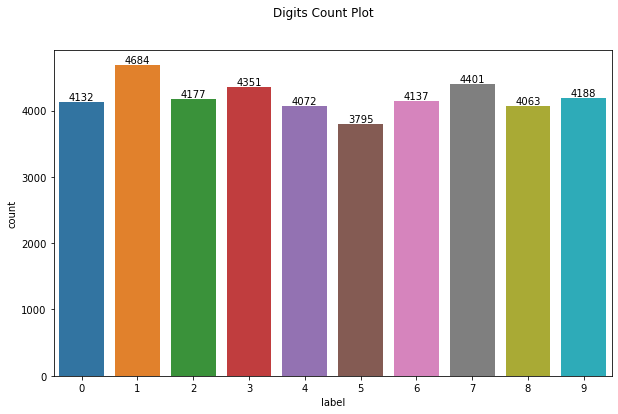

```python
# DIGIT COUNT PLOT
plt.figure(figsize=(10, 6))
ax = sns.countplot(x='label', data=dataset_train)
ax.figure.suptitle('Digits Count Plot')
for container in ax.containers:
    ax.bar_label(container)
plt.show()
```

It shows that they are fairly in equal amounts in the dataset, which means that there is no class imbalance, that may cause bias, misclassification...

The image of the number won't be required in our analysis, however, I would like to show a sample image:

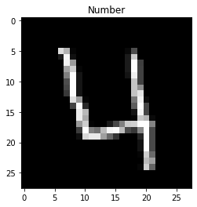

```python
num = dataset_train.iloc[3, 1:]
num.shape
num = num.values.reshape(28,28)
plt.imshow(num, cmap='gray')
plt.title("Number")
```

## Models (SVC, RandomForest, KNN, GaussianNB)

#### Helper Functions

Before getting into the Model creation, a few functions that will be repeatedly used will be defined in order to ease the reporting process:

```python
### Confusion Matrix
def plot_confusion_matrix(conf_matrix, ax):
    norm_conf_matrix = conf_matrix.astype('float') / conf_matrix.sum(axis=1, keepdims=True)
    np.fill_diagonal(norm_conf_matrix, 0)
    sns.heatmap(norm_conf_matrix, ax=ax, annot=False, cmap="coolwarm", fmt='.0f')
    for i in range(len(conf_matrix)):
        for j in range(len(conf_matrix)):
            plt.text(j+0.5, i+0.5, conf_matrix[i][j], ha='center', va='center')
    plt.title('Confusion matrix')
    plt.tight_layout()
    plt.ylabel('True label')
    plt.xlabel('Predicted label')
```

```python
### Classification Report
def plot_classif_report(clf_report, ax, vmin=0.93, vmax=1):
    mask1 = np.zeros_like(clf_report, dtype=bool)
    mask1[10:, :] = True
    mask2 = np.zeros_like(clf_report, dtype=bool)
    mask2[:10, :] = True
    cmap_white = ListedColormap(['white'])
    sns.heatmap(clf_report, ax=ax, mask=mask1, annot=True, cmap='viridis', fmt='.6f', vmin=vmin, vmax=vmax, cbar=False)
    sns.heatmap(clf_report, ax=ax, mask=mask2, annot=True, cmap=cmap_white, fmt='.6f', cbar=False)
    ax.set_title("Classification report", fontsize=10, pad=10)
    ax.xaxis.tick_top()
    ax.xaxis.set_label_position('top')
```

```python
### Evaluation Report
def print_eval_report(y_actual, y_predicted):
    # accuracy score print
    accuracy = accuracy_score(y_actual, y_predicted)
    print('Accuracy: {:.4f}%'.format(accuracy*100))
    # confusion matrix
    conf_mx = confusion_matrix(y_actual, y_predicted)
    classif_report_df = pd.DataFrame(classification_report(y_actual, y_predicted, output_dict=True)).iloc[:-1, :].T
    fig,(ax0, ax1) = plt.subplots(1,2,figsize=(10,5), sharex=False, gridspec_kw={'width_ratios': [1, 2.2]}, dpi=100)
    # call functions to classification report and confusion matrix plots
    plot_classif_report(classif_report_df, ax0)
    plot_confusion_matrix(conf_mx, ax1)
    fig.tight_layout()
    plt.show()
```

```python
# Pipeline initiation for grid search use
pipeline = Pipeline([
    ('scaler', None),
    ('pca', None),
    ('model', None)
])
```

```python
# Train and Validation Set Creation from Train Dataset
X_train, X_val, y_train, y_val = train_test_split(dataset_train, dataset_train['label'], test_size=0.25, stratify = dataset_train['label'])
X_train = X_train.drop("label", axis=1)
y_train = y_train.to_numpy()
X_val = X_val.drop("label", axis=1)
y_val = y_val.to_numpy()
print(f'Train shape. \t\tX: {X_train.shape}, y: {y_train.shape}', f'\nValidation shape. \tX: {X_val.shape}, y: {y_val.shape}')
```

```
Train shape. 		X: (31500, 784), y: (31500,)
Validation shape. 	X: (10500, 784), y: (10500,)
```

#### Model Creation & Evaluation using GridSearch

```python
### MODEL AND SCALER CHOOSING USING GRIDSEARCHCV
params = [{
     'model': [ SVC(), RandomForestClassifier(), KNeighborsClassifier(), GaussianNB()],
     'scaler': [MinMaxScaler(), StandardScaler(), Binarizer(threshold=50)]
    }]
### GRID SEARCH
grid_search = GridSearchCV(pipeline, params, cv=3, scoring='f1_macro', n_jobs=-1, verbose=1)
grid_search.fit(X_train[:20000], y_train[:20000])
(pd.DataFrame(grid_search.cv_results_).sort_values(by=['rank_test_score'], ascending=True))
```

```
Fitting 3 folds for each of 12 candidates, totalling 36 fits
```

|  | mean_fit_time | std_fit_time | mean_score_time | std_score_time | param_model | param_scaler | params | split0_test_score | split1_test_score | split2_test_score | mean_test_score | std_test_score | rank_test_score |
| --- | --- | --- | --- | --- | --- | --- | --- | --- | --- | --- | --- | --- | --- |
| 0 | 37.671084 | 0.238083 | 16.034080 | 0.114285 | SVC() | MinMaxScaler() | {'model': SVC(), 'scaler': MinMaxScaler()} | 0.962485 | 0.965484 | 0.965302 | 0.964424 | 0.001373 | 1 |
| 2 | 36.428772 | 5.417554 | 15.512615 | 1.589083 | SVC() | Binarizer(threshold=50) | {'model': SVC(), 'scaler': Binarizer(threshold... | 0.959214 | 0.963052 | 0.963225 | 0.961830 | 0.001852 | 2 |
| 5 | 4.057162 | 0.049090 | 0.265693 | 0.010441 | RandomForestClassifier() | Binarizer(threshold=50) | {'model': RandomForestClassifier(), 'scaler': ... | 0.954278 | 0.954800 | 0.956582 | 0.955220 | 0.000986 | 3 |
| 3 | 7.434025 | 0.048173 | 0.196218 | 0.013082 | RandomForestClassifier() | MinMaxScaler() | {'model': RandomForestClassifier(), 'scaler': ... | 0.953614 | 0.954241 | 0.953156 | 0.953670 | 0.000445 | 4 |
| 4 | 7.222925 | 0.043422 | 0.212378 | 0.008057 | RandomForestClassifier() | StandardScaler() | {'model': RandomForestClassifier(), 'scaler': ... | 0.950688 | 0.953579 | 0.954756 | 0.953008 | 0.001709 | 5 |
| 6 | 0.169419 | 0.013644 | 15.939386 | 0.168011 | KNeighborsClassifier() | MinMaxScaler() | {'model': KNeighborsClassifier(), 'scaler': Mi... | 0.951333 | 0.952252 | 0.953104 | 0.952230 | 0.000723 | 6 |
| 8 | 0.264728 | 0.014575 | 10.757126 | 2.965866 | KNeighborsClassifier() | Binarizer(threshold=50) | {'model': KNeighborsClassifier(), 'scaler': Bi... | 0.949223 | 0.951003 | 0.951131 | 0.950453 | 0.000871 | 7 |
| 1 | 54.219615 | 0.142641 | 16.918649 | 0.044760 | SVC() | StandardScaler() | {'model': SVC(), 'scaler': StandardScaler()} | 0.940806 | 0.944193 | 0.947982 | 0.944327 | 0.002931 | 8 |
| 7 | 0.467999 | 0.197132 | 15.706264 | 0.545692 | KNeighborsClassifier() | StandardScaler() | {'model': KNeighborsClassifier(), 'scaler': St... | 0.919254 | 0.915436 | 0.916957 | 0.917216 | 0.001570 | 9 |
| 9 | 0.406158 | 0.175855 | 0.154223 | 0.014957 | GaussianNB() | MinMaxScaler() | {'model': GaussianNB(), 'scaler': MinMaxScaler()} | 0.513893 | 0.557815 | 0.546749 | 0.539486 | 0.018652 | 10 |
| 11 | 0.329946 | 0.042873 | 0.174164 | 0.016091 | GaussianNB() | Binarizer(threshold=50) | {'model': GaussianNB(), 'scaler': Binarizer(th... | 0.486101 | 0.510384 | 0.516702 | 0.504396 | 0.013191 | 11 |
| 10 | 0.273689 | 0.061713 | 0.138605 | 0.006517 | GaussianNB() | StandardScaler() | {'model': GaussianNB(), 'scaler': StandardScal... | 0.480488 | 0.526536 | 0.505912 | 0.504312 | 0.018833 | 12 |

The table above shows various models and scaler combinations with respective test scores. Using these test scores, the combination is sorted from best to least.

```python
grid_search.best_params_
```

```
{'model': SVC(), 'scaler': MinMaxScaler()}
```

The grid search shows that the best model with highest f1 score is the SVC model with a MinMaxScaler. Now using the best model and parameters, let's take a look at the classification and confusion matrix.

```python
# get the best model, predict validation labels
best_grid_model = grid_search.best_estimator_
y_val_predict = best_grid_model.predict(X_val)
```

```
Accuracy: 96.7524%
```

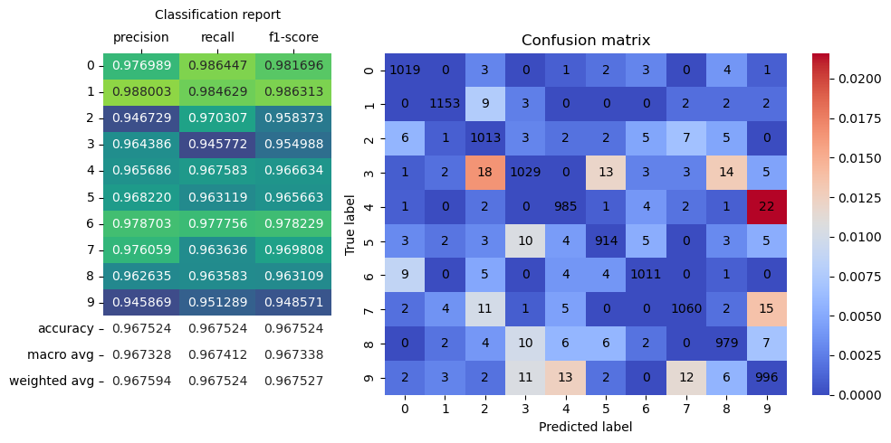

```python
# EVAL REPORT
print_eval_report(y_val, y_val_predict)
```

The classification report above shows precision, recall and f1-score for each number. Highest scores are in numbers 0 and 1.

The confusion matrix shows that the number 3 is most confused with 2, 5 and 8. The confusion matrix shows that the number 9 is most confused with 3, 4 and 7.

The highest number of mispredicting is with number 4 being predicted number 9.

Reported accuracy of the best model {'model': SVC(), 'scaler': MinMaxScaler()} constructed from the GridSearch is 96.7524%, which is quite high, but will still be tried to fine tune using PCA and hyperparameter tuning.

From the analysis above, we have seen that the SVM with a kernel function is the most powerful classification algorithm, however, to achieve better performance on SVC model, there are several improvements that can be applied:

- PCA: Apply PCA (Principal Component Analysis) or other dimensionality reduction techniques to reduce the number of features without losing too much information.
- Hyperparameter Tuning: Optimize the regularization parameter (C) to control the trade-off between overfitting and underfitting. A smaller C value creates a wider margin, allowing for more misclassifications but better generalization. A larger C value creates a narrower margin, reducing misclassifications at the cost of potentially overfitting the model. For the RBF kernel, optimize the gamma parameter, which determines the shape of the decision boundary. A low gamma value produces a more flexible decision boundary, while a high gamma value produces a more rigid decision boundary. Use techniques like Grid Search or Randomized Search to find the optimal combination of hyperparameters.
- Kernel Selection: Experiment with different kernel functions, such as linear, polynomial, Radial Basis Function (RBF), and sigmoid, to find the one that works best for your dataset. RBF is commonly used with good results, but it's always a good idea to test other options.

### Applying PCA to SVC model

```python
# Min-Max Scale
min_max_scaler = MinMaxScaler()
X_train_scaled = min_max_scaler.fit_transform(X_train)

# PCA
pca = PCA(n_components=400)
pca.fit(X_train_scaled)
```

```
PCA(n_components=400)
```

Since GRIDSEARCHCV is taking a long time to process, HalvingGridSearchCV is utilized.

```python
params = [{
    'model': [SVC()],
    'scaler': [MinMaxScaler()],
    'pca': [PCA()],
    'pca__n_components': [2, 10, 25, 50, 75, 80, 100, 120, 150]
    }]

# GRIDSEARCHCV
grid_search_pca = HalvingGridSearchCV(pipeline, params, cv=3,scoring='f1_macro', n_jobs=-1, verbose=1)
grid_search_pca.fit(X_train, y_train)
(pd.DataFrame(grid_search_pca.cv_results_).sort_values(by=['rank_test_score'], ascending=True))
```

```
n_iterations: 3
n_required_iterations: 3
n_possible_iterations: 3
min_resources_: 3500
max_resources_: 31500
aggressive_elimination: False
factor: 3
----------
iter: 0
n_candidates: 9
n_resources: 3500
Fitting 3 folds for each of 9 candidates, totalling 27 fits
----------
iter: 1
n_candidates: 3
n_resources: 10500
Fitting 3 folds for each of 3 candidates, totalling 9 fits
----------
iter: 2
n_candidates: 1
n_resources: 31500
Fitting 3 folds for each of 1 candidates, totalling 3 fits
```

|  | iter | n_resources | mean_fit_time | std_fit_time | mean_score_time | std_score_time | param_model | param_pca | param_pca__n_components | param_scaler | ... | split1_test_score | split2_test_score | mean_test_score | std_test_score | rank_test_score | split0_train_score | split1_train_score | split2_train_score | mean_train_score | std_train_score |
| --- | --- | --- | --- | --- | --- | --- | --- | --- | --- | --- | --- | --- | --- | --- | --- | --- | --- | --- | --- | --- | --- |
| 12 | 2 | 31500 | 7.468110 | 0.029206 | 8.352513 | 0.122756 | SVC() | PCA(n_components=50) | 50 | MinMaxScaler() | ... | 0.977530 | 0.978342 | 0.977008 | 0.001354 | 1 | 0.989910 | 0.988834 | 0.989087 | 0.989277 | 0.000460 |
| 11 | 1 | 10500 | 2.153667 | 0.218961 | 1.894902 | 0.632154 | SVC() | PCA(n_components=50) | 50 | MinMaxScaler() | ... | 0.964671 | 0.967160 | 0.965893 | 0.001016 | 2 | 0.987841 | 0.987989 | 0.986577 | 0.987469 | 0.000634 |
| 9 | 1 | 10500 | 3.284367 | 0.692539 | 2.572194 | 0.869921 | SVC() | PCA(n_components=50) | 75 | MinMaxScaler() | ... | 0.964031 | 0.967454 | 0.965862 | 0.001408 | 3 | 0.988613 | 0.989570 | 0.988046 | 0.988743 | 0.000629 |
| 10 | 1 | 10500 | 2.742614 | 0.060615 | 2.035155 | 0.032581 | SVC() | PCA(n_components=50) | 100 | MinMaxScaler() | ... | 0.964046 | 0.966511 | 0.965751 | 0.001208 | 4 | 0.990026 | 0.990006 | 0.989480 | 0.989837 | 0.000253 |
| 3 | 0 | 3500 | 0.525106 | 0.003770 | 0.259081 | 0.012239 | SVC() | PCA(n_components=50) | 50 | MinMaxScaler() | ... | 0.957316 | 0.956280 | 0.949418 | 0.010446 | 5 | 0.986914 | 0.985503 | 0.987610 | 0.986676 | 0.000876 |
| 6 | 0 | 3500 | 0.629784 | 0.012161 | 0.336448 | 0.014924 | SVC() | PCA(n_components=50) | 100 | MinMaxScaler() | ... | 0.952334 | 0.955551 | 0.946530 | 0.010565 | 6 | 0.990278 | 0.990163 | 0.991851 | 0.990764 | 0.000770 |
| 4 | 0 | 3500 | 0.899609 | 0.046529 | 0.421295 | 0.067827 | SVC() | PCA(n_components=50) | 75 | MinMaxScaler() | ... | 0.954773 | 0.952852 | 0.946522 | 0.010340 | 7 | 0.990708 | 0.988490 | 0.990966 | 0.990055 | 0.001111 |
| 5 | 0 | 3500 | 0.608823 | 0.075328 | 0.333615 | 0.019719 | SVC() | PCA(n_components=50) | 80 | MinMaxScaler() | ... | 0.955533 | 0.952852 | 0.946522 | 0.010903 | 8 | 0.990341 | 0.989347 | 0.990966 | 0.990218 | 0.000667 |
| 7 | 0 | 3500 | 0.914367 | 0.199022 | 0.346780 | 0.012170 | SVC() | PCA(n_components=50) | 120 | MinMaxScaler() | ... | 0.950000 | 0.954745 | 0.945774 | 0.009531 | 9 | 0.991223 | 0.990163 | 0.991851 | 0.991079 | 0.000697 |
| 2 | 0 | 3500 | 0.527717 | 0.088989 | 0.168232 | 0.010645 | SVC() | PCA(n_components=50) | 25 | MinMaxScaler() | ... | 0.952226 | 0.953002 | 0.945635 | 0.009875 | 10 | 0.979190 | 0.975863 | 0.980045 | 0.978366 | 0.001804 |
| 8 | 0 | 3500 | 0.824180 | 0.017365 | 0.268075 | 0.003599 | SVC() | PCA(n_components=50) | 150 | MinMaxScaler() | ... | 0.950732 | 0.952889 | 0.945469 | 0.009011 | 11 | 0.991111 | 0.991083 | 0.992696 | 0.991630 | 0.000754 |
| 1 | 0 | 3500 | 0.502377 | 0.010701 | 0.164465 | 0.002799 | SVC() | PCA(n_components=50) | 10 | MinMaxScaler() | ... | 0.909989 | 0.900182 | 0.898899 | 0.009622 | 12 | 0.931854 | 0.924571 | 0.926280 | 0.927568 | 0.003110 |
| 0 | 0 | 3500 | 0.572253 | 0.032593 | 0.347420 | 0.008099 | SVC() | PCA(n_components=50) | 2 | MinMaxScaler() | ... | 0.389727 | 0.432239 | 0.412364 | 0.017465 | 13 | 0.442256 | 0.418563 | 0.411411 | 0.424077 | 0.013182 |

13 rows × 22 columns

```python
print("Best model with optimized parameters:",grid_search_pca.best_params_)
```

```
Best model with optimized parameters: {'model': SVC(), 'pca': PCA(n_components=50), 'pca__n_components': 50, 'scaler': MinMaxScaler()}
```

```
Accuracy: 97.9810%
```

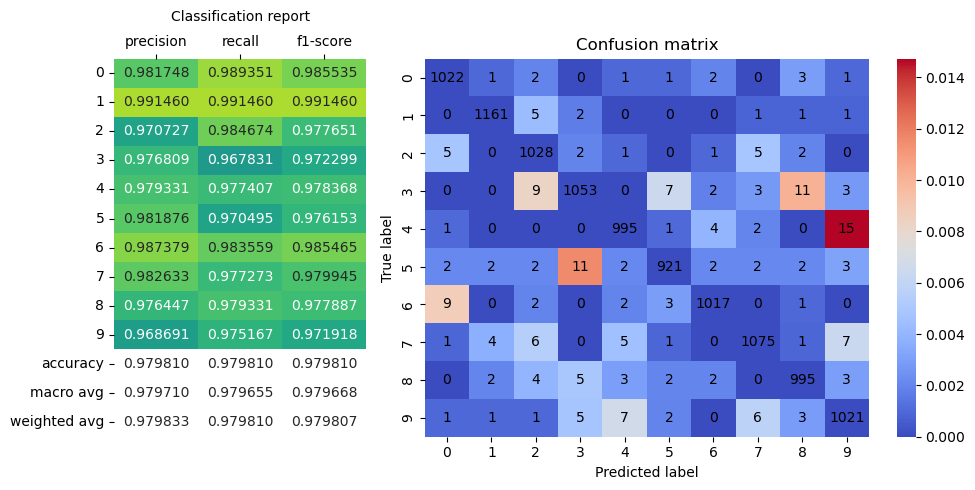

```python
# Evaluation Report
pca_estimator = grid_search_pca.best_estimator_
y_val_predicted_pca = pca_estimator.predict(X_val)
print_eval_report(y_val, y_val_predicted_pca)
```

Evaluation above shows that accuracy is **increased** after PCA application on SVC model. This shows that using PCA and cutting down the number of features used for classification, helps to **increase** the model accuracy.

### Hyperparameter Tuning of SVC

HalvingGridSearchCV is a great alternative to GridSearchCV when it comes to reducing the computational burden of hyperparameter tuning. It is an implementation of the successive halving algorithm, which is designed to find good hyperparameter combinations more quickly.

```python
params_tune = [{
        'model': [SVC()],
        'model__kernel': ['linear', 'rbf'],
        'model__C': [0.1, 0.5, 1, 10, 25, 50, 100],
        'model__gamma': [0.001, 0.01, 0.1, 1, 10],
        'scaler': [MinMaxScaler()],
        'pca': [PCA()],
        'pca__n_components': [50]
    },
]
# GRIDSEARCHCV
grid_search_hyper = HalvingGridSearchCV(pipeline, params_tune, cv=5, scoring='f1_macro', verbose=1, n_jobs=-1, min_resources=360)
grid_search_hyper.fit(X_train, y_train)
(pd.DataFrame(grid_search_hyper.cv_results_).sort_values(by=['rank_test_score'], ascending=True).head())
```

```
n_iterations: 4
n_required_iterations: 4
n_possible_iterations: 5
min_resources_: 360
max_resources_: 31500
aggressive_elimination: False
factor: 3
----------
iter: 0
n_candidates: 70
n_resources: 360
Fitting 5 folds for each of 70 candidates, totalling 350 fits
----------
iter: 1
n_candidates: 24
n_resources: 1080
Fitting 5 folds for each of 24 candidates, totalling 120 fits
----------
iter: 2
n_candidates: 8
n_resources: 3240
Fitting 5 folds for each of 8 candidates, totalling 40 fits
----------
iter: 3
n_candidates: 3
n_resources: 9720
Fitting 5 folds for each of 3 candidates, totalling 15 fits
```

|  | iter | n_resources | mean_fit_time | std_fit_time | mean_score_time | std_score_time | param_model | param_model__C | param_model__gamma | param_model__kernel | ... | mean_test_score | std_test_score | rank_test_score | split0_train_score | split1_train_score | split2_train_score | split3_train_score | split4_train_score | mean_train_score | std_train_score |
| --- | --- | --- | --- | --- | --- | --- | --- | --- | --- | --- | --- | --- | --- | --- | --- | --- | --- | --- | --- | --- | --- |
| 104 | 3 | 9720 | 1.768498 | 0.104114 | 0.669957 | 0.044983 | SVC(C=10, gamma=0.01) | 10 | 0.01 | rbf | ... | 0.964871 | 0.004514 | 1 | 0.997857 | 0.997065 | 0.996970 | 0.996073 | 0.997309 | 0.997055 | 0.000580 |
| 103 | 3 | 9720 | 2.197295 | 0.698175 | 0.763065 | 0.069838 | SVC(C=10, gamma=0.01) | 50 | 0.01 | rbf | ... | 0.964265 | 0.004681 | 2 | 0.999874 | 0.999875 | 1.000000 | 1.000000 | 0.999872 | 0.999924 | 0.000062 |
| 102 | 3 | 9720 | 2.031924 | 0.027746 | 0.835833 | 0.195219 | SVC(C=10, gamma=0.01) | 25 | 0.01 | rbf | ... | 0.963510 | 0.004423 | 3 | 0.999627 | 0.999748 | 0.999744 | 0.999496 | 0.999491 | 0.999621 | 0.000113 |
| 101 | 2 | 3240 | 0.543996 | 0.050809 | 0.135002 | 0.033056 | SVC(C=10, gamma=0.01) | 10 | 0.01 | rbf | ... | 0.942205 | 0.006903 | 4 | 0.999210 | 0.999634 | 0.998903 | 0.998842 | 0.998502 | 0.999018 | 0.000381 |
| 100 | 2 | 3240 | 0.557712 | 0.066669 | 0.138649 | 0.024484 | SVC(C=10, gamma=0.01) | 50 | 0.01 | rbf | ... | 0.941811 | 0.005604 | 5 | 1.000000 | 1.000000 | 1.000000 | 1.000000 | 1.000000 | 1.000000 | 0.000000 |

5 rows × 29 columns

```python
print("Best model with optimized hyperparameters:",grid_search_hyper.best_params_)
```

```
Best model with optimized hyperparameters: {'model': SVC(C=10, gamma=0.01), 'model__C': 10, 'model__gamma': 0.01, 'model__kernel': 'rbf', 'pca': PCA(n_components=50), 'pca__n_components': 50, 'scaler': MinMaxScaler()}
```

```
Accuracy: 98.0952%
```

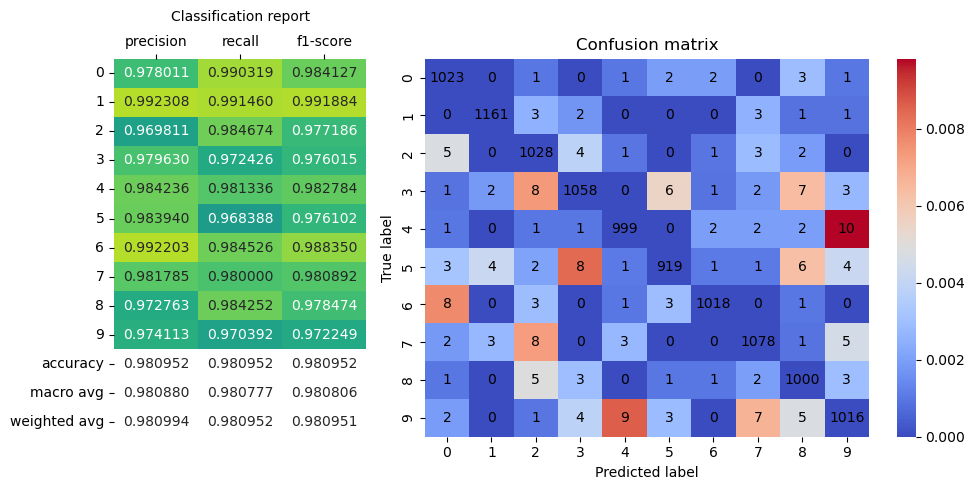

```python
# Evaluation Report
hyper_estimator = grid_search_hyper.best_estimator_
y_val_predicted_hyper = hyper_estimator.predict(X_val)
print_eval_report(y_val, y_val_predicted_hyper)
```

The evaluation report above shows the precision, recall and f1-score for each number. The ovarall accurayc has increased to 98.0952%. The confusion matrix shows that number 4 is still being confused the most with number 9, but the number of misclassifying has decreased.

Now that we have a high accuracy model, it is time to classify test data using the best performing model.

## Evaluation

The model hyperparameter tuning and use of PCA have showed us that the best model with optimized hyperparameters is:

- SVC (C=10, gamma=0.01) with a model__kernel of 'rbf', with PCA(n_components=50), and with a MinMaxScaler.

```python
# Predict test labels
test_predictions = hyper_estimator.predict(dataset_test.to_numpy())
```

```python
# Validate the model on the validation data
y_val_pred = hyper_estimator.predict(X_val)
val_accuracy = accuracy_score(y_val, y_val_pred)
print(f"Validation accuracy: {val_accuracy:.4f}")

# Test the model on the dataset_test
y_test_pred = hyper_estimator.predict(dataset_test)
test_accuracy = accuracy_score(correct_test_labels, y_test_pred)
print(f"Test accuracy: {test_accuracy:.4f}")
```

```
Validation accuracy: 0.9810
Test accuracy: 0.9789
```

```
Accuracy: 97.8857%
```

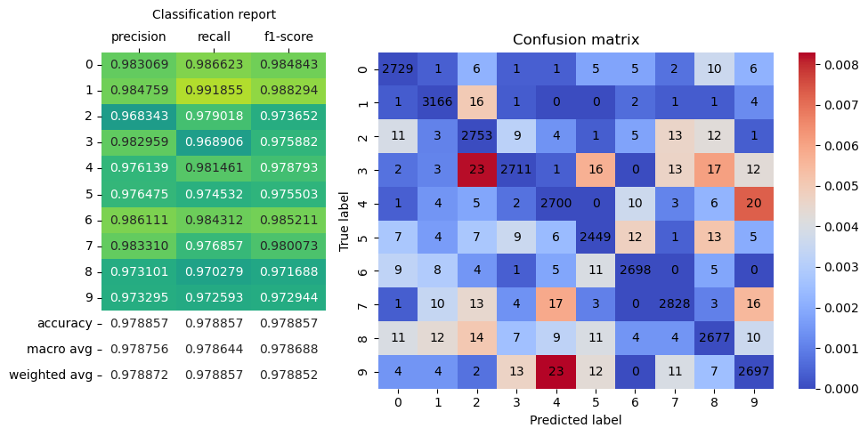

```python
print_eval_report(correct_test_labels, test_predictions)
```

## Conclusion & Future Improvements

The evaluation report above shows that the test accuracy is 97.8857% and the validation accuracy is 0.9810. Using an SVC (C=10, gamma=0.01) with a model kernel of 'rbf', PCA(n_components=50), and a MinMaxScaler, model proved to be the best performing in terms of f1 score.

The confusion matrix shows that the highest misclassification is with number 3 being mislabeled as 2 and number 9 being mislabeled as 4, with both 23 misclassifications.

Overall, the testing and validation accuracies are quite high both close to 98 %. Using hyperparameter tuning, PCA and GridSearch, the best model was developed and tested.

Future improvements might include:

- Data Augmentation: Data augmentation is a method that slightly alters the training data in order to create more training samples with correct labels, which can be further used to train a more comprehensive model that can be more accurate.